# Factors of savings: Lima Case

## NumMembersAtHome

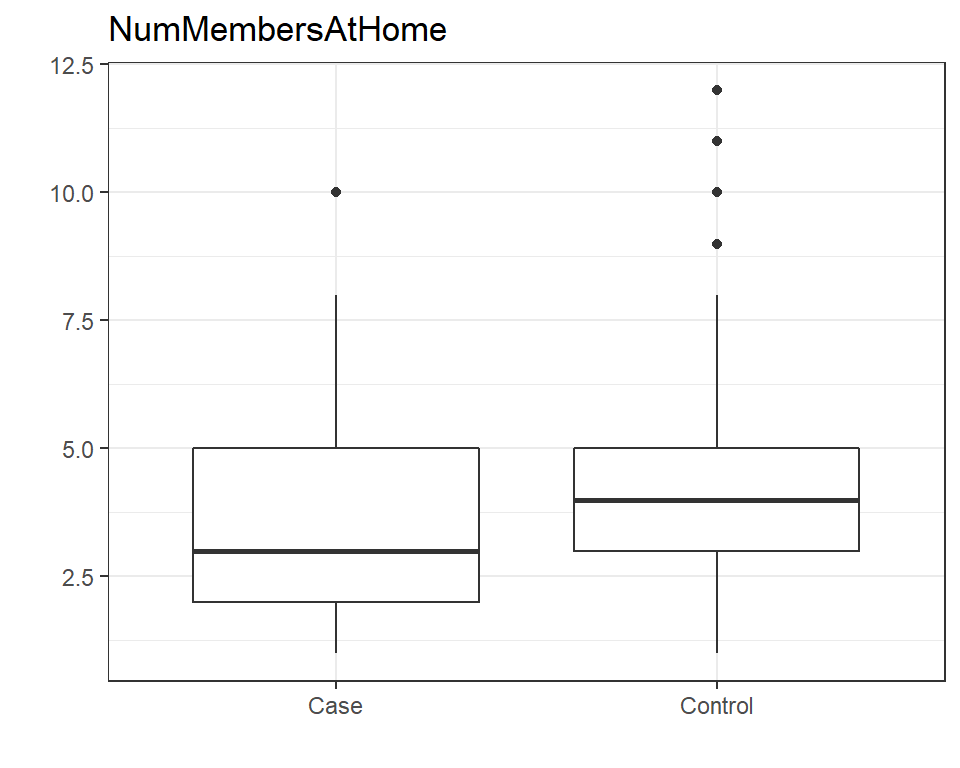

Results of univariate logit

|  | Estimate | Std..Error | z.value | Pr…z.. |
| --- | --- | --- | --- | --- |
| (Intercept) | -0.8529278 | 0.1978362 | -4.311283 | 0.0000162 |
| data[, i] | 0.1357396 | 0.0466388 | 2.910442 | 0.0036092 |

Odds Ratio

|  | OR | X2.5.. | X97.5.. |
| --- | --- | --- | --- |
| (Intercept) | 0.4261654 | 0.2877692 | 0.6256423 |
| data[, i] | 1.1453836 | 1.0460733 | 1.2564215 |

H0: The coefficient of Savings is zero  
H1: The coefficient of Savings is not zero  
Result: Reject H0. With 95% of confidence it could be affirmed that the coefficient of Savings is not zero

## Education

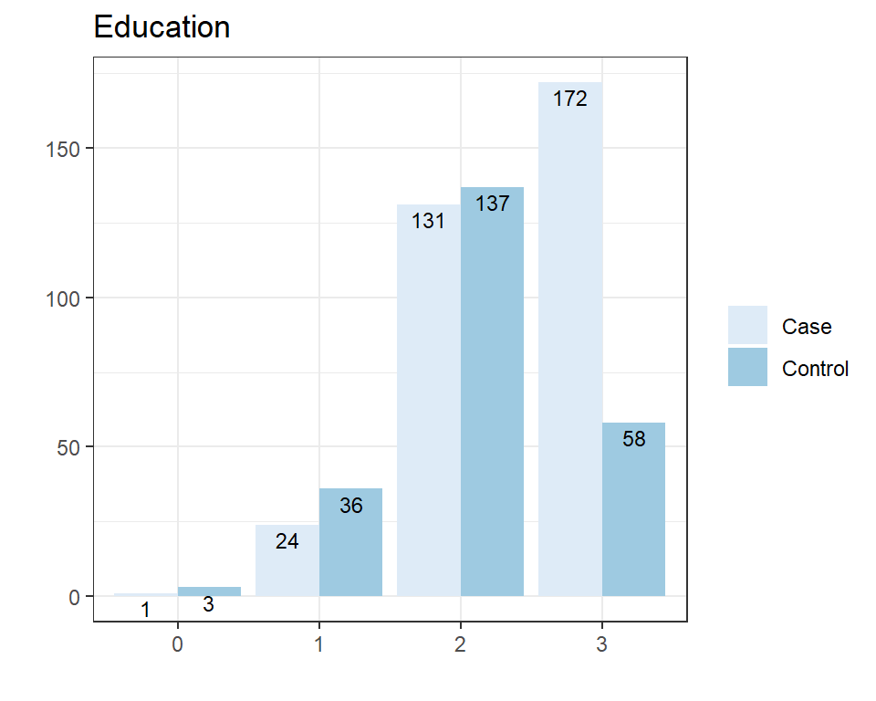

Table of Frequencies

| Education | Case | % Case | Control | % Control |
| --- | --- | --- | --- | --- |
| 0 | 1 | 0.30 | 3 | 1.28 |
| 1 | 24 | 7.32 | 36 | 15.38 |
| 2 | 131 | 39.94 | 137 | 58.55 |
| 3 | 172 | 52.44 | 58 | 24.79 |

Chi square test of independence

| Variable | Statistic | Parameter | p.value |
| --- | --- | --- | --- |
| Education | 45.59172 | 3 | 0 |

H0: Savings and Education are independent  
H1: Savings and Education are not independent  
Result: Reject H0. With 95% of confidence it could be affirmed that Savings and Education are not independent

## Sex

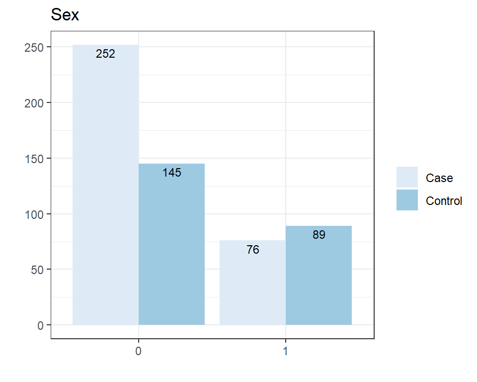

Table of Frequencies

| Sex | Case | % Case | Control | % Control |
| --- | --- | --- | --- | --- |
| 0 | 252 | 76.83 | 145 | 61.97 |
| 1 | 76 | 23.17 | 89 | 38.03 |

Chi square test of independence

| Variable | Statistic | Parameter | p.value |
| --- | --- | --- | --- |
| Sex | 14.54759 | 1 | 0.0001367 |

H0: Savings and Sex are independent  
H1: Savings and Sex are not independent  
Result: Reject H0. With 95% of confidence it could be affirmed that Savings and Sex are not independent

## Income

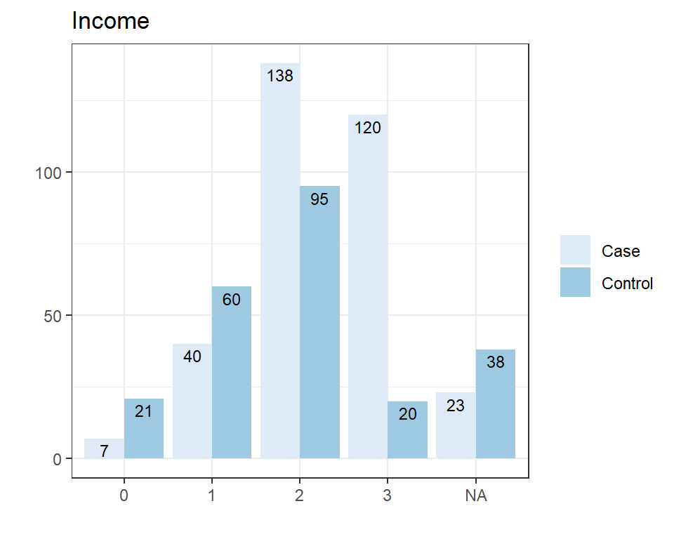

Table of Frequencies

| Income | Case | % Case | Control | % Control |
| --- | --- | --- | --- | --- |
| 0 | 7 | 2.30 | 21 | 10.71 |
| 1 | 40 | 13.11 | 60 | 30.61 |
| 2 | 138 | 45.25 | 95 | 48.47 |
| 3 | 120 | 39.34 | 20 | 10.20 |

Chi square test of independence

| Variable | Statistic | Parameter | p.value |
| --- | --- | --- | --- |
| Income | 69.9612 | 3 | 0 |

H0: Savings and Income are independent  
H1: Savings and Income are not independent  
Result: Reject H0. With 95% of confidence it could be affirmed that Savings and Income are not independent